# day-1-session-2

## Data Preprocessing (Data Wrangling)

Data wrangling is a broad term used, often informally, to describe the process of transforming raw data to a clean and organized format ready for use.

```python
import pandas as pd
```

```python
url = 'https://raw.githubusercontent.com/chrisalbon/simulated_datasets/master/titanic.csv'

# Load data as a dataframe
dataframe = pd.read_csv(url)

# Show first 5 rows
dataframe.head(5)
```

|  | Name | PClass | Age | Sex | Survived | SexCode |
| --- | --- | --- | --- | --- | --- | --- |
| 0 | Allen, Miss Elisabeth Walton | 1st | 29.00 | female | 1 | 1 |
| 1 | Allison, Miss Helen Loraine | 1st | 2.00 | female | 0 | 1 |
| 2 | Allison, Mr Hudson Joshua Creighton | 1st | 30.00 | male | 0 | 0 |
| 3 | Allison, Mrs Hudson JC (Bessie Waldo Daniels) | 1st | 25.00 | female | 0 | 1 |
| 4 | Allison, Master Hudson Trevor | 1st | 0.92 | male | 1 | 0 |

There are three important things to notice in this data frame.

**First**, in a data frame each row corresponds to one observation (e.g., a passenger) and each column corresponds to one feature (gender, age, etc.). For example, by looking at the first observation we can see that Miss Elisabeth Walton Allen stayed in first class, was 29 years old, was female, and survived the disaster.

**Second**, each column contains a name (e.g., Name, PClass, Age) and each row contains an index number (e.g., 0 for the lucky Miss Elisabeth Walton Allen). We will use these to select and manipulate observations and features.

**Third**, two columns, Sex and SexCode, contain the same information in different formats. In Sex, a woman is indicated by the string female, while in SexCode, a woman is indicated by using the integer 1. We will want all our features to be unique, and therefore we will need to remove one of these columns.

```python
# Show dimensions
dataframe.shape
```

```
(1313, 6)
```

```python
# Show statistics
dataframe.describe()
```

|  | Age | Survived | SexCode |
| --- | --- | --- | --- |
| count | 756.000000 | 1313.000000 | 1313.000000 |
| mean | 30.397989 | 0.342727 | 0.351866 |
| std | 14.259049 | 0.474802 | 0.477734 |
| min | 0.170000 | 0.000000 | 0.000000 |
| 25% | 21.000000 | 0.000000 | 0.000000 |
| 50% | 28.000000 | 0.000000 | 0.000000 |
| 75% | 39.000000 | 1.000000 | 1.000000 |
| max | 71.000000 | 1.000000 | 1.000000 |

```python
# Show top two rows where column 'sex' is 'female'
dataframe[dataframe['Sex'] == 'female'].head(2)
```

|  | Name | PClass | Age | Sex | Survived | SexCode |
| --- | --- | --- | --- | --- | --- | --- |
| 0 | Allen, Miss Elisabeth Walton | 1st | 29.0 | female | 1 | 1 |
| 1 | Allison, Miss Helen Loraine | 1st | 2.0 | female | 0 | 1 |

```python
# Replace values, show two rows
dataframe['Sex'].replace("female", "Woman").head(2)
```

```
0    Woman
1    Woman
Name: Sex, dtype: object
```

```python
# Replace "female" and "male with "Woman" and "Man"
dataframe['Sex'].replace(["female", "male"], ["Woman", "Man"]).head(5)
```

```
0    Woman
1    Woman
2      Man
3    Woman
4      Man
Name: Sex, dtype: object
```

```python
# Replace values, show two rows, in the whole dataframe
dataframe.replace(1, "One").head(2)
```

|  | Name | PClass | Age | Sex | Survived | SexCode |
| --- | --- | --- | --- | --- | --- | --- |
| 0 | Allen, Miss Elisabeth Walton | 1st | 29.0 | female | One | One |
| 1 | Allison, Miss Helen Loraine | 1st | 2.0 | female | 0 | One |

```python
# Rename column, show two rows
dataframe.rename(columns={'PClass': 'Passenger Class'}).head(2)
```

|  | Name | Passenger Class | Age | Sex | Survived | SexCode |
| --- | --- | --- | --- | --- | --- | --- |
| 0 | Allen, Miss Elisabeth Walton | 1st | 29.0 | female | 1 | 1 |
| 1 | Allison, Miss Helen Loraine | 1st | 2.0 | female | 0 | 1 |

```python
# Rename columns, show two rows
dataframe.rename(columns={'PClass': 'Passenger Class', 'Sex': 'Gender'}).head(2)
```

|  | Name | Passenger Class | Age | Gender | Survived | SexCode |
| --- | --- | --- | --- | --- | --- | --- |
| 0 | Allen, Miss Elisabeth Walton | 1st | 29.0 | female | 1 | 1 |
| 1 | Allison, Miss Helen Loraine | 1st | 2.0 | female | 0 | 1 |

```python
# Calculate statistics
print('Maximum:', dataframe['Age'].max())
print('Minimum:', dataframe['Age'].min())
print('Mean:', dataframe['Age'].mean())
print('Sum:', dataframe['Age'].sum())
print('Count:', dataframe['Age'].count())
```

```
Maximum: 71.0
Minimum: 0.17
Mean: 30.397989417989418
Sum: 22980.88
Count: 756
```

```python
# Select unique values
dataframe['Sex'].unique()
```

```
array(['female', 'male'], dtype=object)
```

```python
# Show counts
dataframe['Sex'].value_counts()
```

```
male      851
female    462
Name: Sex, dtype: int64
```

```python
## Select missing values, show two rows
dataframe[dataframe['Age'].isnull()]
```

|  | Name | PClass | Age | Sex | Survived | SexCode |
| --- | --- | --- | --- | --- | --- | --- |
| 12 | Aubert, Mrs Leontine Pauline | 1st | NaN | female | 1 | 1 |
| 13 | Barkworth, Mr Algernon H | 1st | NaN | male | 1 | 0 |
| 14 | Baumann, Mr John D | 1st | NaN | male | 0 | 0 |
| 29 | Borebank, Mr John James | 1st | NaN | male | 0 | 0 |
| 32 | Bradley, Mr George | 1st | NaN | male | 1 | 0 |
| ... | ... | ... | ... | ... | ... | ... |
| 1300 | Wiseman, Mr Phillippe | 3rd | NaN | male | 0 | 0 |
| 1302 | Yalsevac, Mr Ivan | 3rd | NaN | male | 1 | 0 |
| 1305 | Youssef, Mr Gerios | 3rd | NaN | male | 0 | 0 |
| 1306 | Zabour, Miss Hileni | 3rd | NaN | female | 0 | 1 |
| 1307 | Zabour, Miss Tamini | 3rd | NaN | female | 0 | 1 |

557 rows × 6 columns

```python
# Load library
import numpy as np

# Replace values with NaN
dataframe['Sex'] = dataframe['Sex'].replace('male', np.nan)
```

```python
dataframe.head(5)
```

|  | Name | PClass | Age | Sex | Survived | SexCode |
| --- | --- | --- | --- | --- | --- | --- |
| 0 | Allen, Miss Elisabeth Walton | 1st | 29.00 | female | 1 | 1 |
| 1 | Allison, Miss Helen Loraine | 1st | 2.00 | female | 0 | 1 |
| 2 | Allison, Mr Hudson Joshua Creighton | 1st | 30.00 | NaN | 0 | 0 |
| 3 | Allison, Mrs Hudson JC (Bessie Waldo Daniels) | 1st | 25.00 | female | 0 | 1 |
| 4 | Allison, Master Hudson Trevor | 1st | 0.92 | NaN | 1 | 0 |

```python
# Delete column
dataframe.drop('Age', axis=1).head(2)
```

|  | Name | PClass | Sex | Survived | SexCode |
| --- | --- | --- | --- | --- | --- |
| 0 | Allen, Miss Elisabeth Walton | 1st | female | 1 | 1 |
| 1 | Allison, Miss Helen Loraine | 1st | female | 0 | 1 |

```python
# Drop columns
dataframe.drop(['Age', 'Sex'], axis=1).head(2)
```

|  | Name | PClass | Survived | SexCode |
| --- | --- | --- | --- | --- |
| 0 | Allen, Miss Elisabeth Walton | 1st | 1 | 1 |
| 1 | Allison, Miss Helen Loraine | 1st | 0 | 1 |

```python
# Drop column
dataframe.drop(dataframe.columns[1], axis=1).head(2)
```

|  | Name | Age | Sex | Survived | SexCode |
| --- | --- | --- | --- | --- | --- |
| 0 | Allen, Miss Elisabeth Walton | 29.0 | female | 1 | 1 |
| 1 | Allison, Miss Helen Loraine | 2.0 | female | 0 | 1 |

```python
# Delete rows, show first two rows of output
dataframe[dataframe['Sex'] != 'male'].head(2)
```

|  | Name | PClass | Age | Sex | Survived | SexCode |
| --- | --- | --- | --- | --- | --- | --- |
| 0 | Allen, Miss Elisabeth Walton | 1st | 29.0 | female | 1 | 1 |
| 1 | Allison, Miss Helen Loraine | 1st | 2.0 | female | 0 | 1 |

```python
# Drop duplicates, show first two rows of output
dataframe.drop_duplicates().head(2)
```

|  | Name | PClass | Age | Sex | Survived | SexCode |
| --- | --- | --- | --- | --- | --- | --- |
| 0 | Allen, Miss Elisabeth Walton | 1st | 29.0 | female | 1 | 1 |
| 1 | Allison, Miss Helen Loraine | 1st | 2.0 | female | 0 | 1 |

```python
# Group rows by the values of the column 'Sex', calculate mean
# of each group
dataframe.groupby('Sex').mean()
```

| Sex | Age | Survived | SexCode |
| --- | --- | --- | --- |
| female | 29.396424 | 0.666667 | 1.0 |

```python
# Create function
def uppercase(x):
 return x.upper()
```

```python
# Apply function, show two rows
dataframe['Name'].apply(uppercase)[0:2]
```

```
0    ALLEN, MISS ELISABETH WALTON
1     ALLISON, MISS HELEN LORAINE
Name: Name, dtype: object
```

```python
# Group rows, apply function to groups
dataframe.groupby('Sex').apply(lambda x: x.count())
```

| Sex | Name | PClass | Age | Sex | Survived | SexCode |
| --- | --- | --- | --- | --- | --- | --- |
| female | 462 | 462 | 288 | 462 | 462 | 462 |

```python
data_a = {'id': ['1', '2', '3'],
 'first': ['Alex', 'Amy', 'Allen'],
 'last': ['Anderson', 'Ackerman', 'Ali']}

dataframe_a = pd.DataFrame(data_a, columns = ['id', 'first', 'last'])

# Create DataFrame
data_b = {'id': ['4', '5', '6'],
 'first': ['Billy', 'Brian', 'Bran'],
 'last': ['Bonder', 'Black', 'Balwner']}

dataframe_b = pd.DataFrame(data_b, columns = ['id', 'first', 'last'])

# Concatenate DataFrames by rows
pd.concat([dataframe_a, dataframe_b], axis=0)
```

|  | id | first | last |
| --- | --- | --- | --- |
| 0 | 1 | Alex | Anderson |
| 1 | 2 | Amy | Ackerman |
| 2 | 3 | Allen | Ali |
| 0 | 4 | Billy | Bonder |
| 1 | 5 | Brian | Black |
| 2 | 6 | Bran | Balwner |

```python
# Concatenate DataFrames by columns
pd.concat([dataframe_a, dataframe_b], axis=1)
```

|  | id | first | last | id | first | last |
| --- | --- | --- | --- | --- | --- | --- |
| 0 | 1 | Alex | Anderson | 4 | Billy | Bonder |
| 1 | 2 | Amy | Ackerman | 5 | Brian | Black |
| 2 | 3 | Allen | Ali | 6 | Bran | Balwner |

```python
# Create DataFrame
employee_data = {'employee_id': ['1', '2', '3', '4'],
 'name': ['Amy Jones', 'Allen Keys', 'Alice Bees',
 'Tim Horton']}

dataframe_employees = pd.DataFrame(employee_data, columns = ['employee_id',
 'name'])

# Create DataFrame
sales_data = {'employee_id': ['3', '4', '5', '6'],
 'total_sales': [23456, 2512, 2345, 1455]}

dataframe_sales = pd.DataFrame(sales_data, columns = ['employee_id',
 'total_sales'])

# Merge DataFrames
pd.merge(dataframe_employees, dataframe_sales, on='employee_id')
```

|  | employee_id | name | total_sales |
| --- | --- | --- | --- |
| 0 | 3 | Alice Bees | 23456 |
| 1 | 4 | Tim Horton | 2512 |

```python
# Merge DataFrames
pd.merge(dataframe_employees, dataframe_sales, on='employee_id', how='outer')
```

|  | employee_id | name | total_sales |
| --- | --- | --- | --- |
| 0 | 1 | Amy Jones | NaN |
| 1 | 2 | Allen Keys | NaN |
| 2 | 3 | Alice Bees | 23456.0 |
| 3 | 4 | Tim Horton | 2512.0 |
| 4 | 5 | NaN | 2345.0 |
| 5 | 6 | NaN | 1455.0 |

```python
# Merge DataFrames
pd.merge(dataframe_employees, dataframe_sales, on='employee_id', how='left')
```

|  | employee_id | name | total_sales |
| --- | --- | --- | --- |
| 0 | 1 | Amy Jones | NaN |
| 1 | 2 | Allen Keys | NaN |
| 2 | 3 | Alice Bees | 23456.0 |
| 3 | 4 | Tim Horton | 2512.0 |

```python
# Merge DataFrames
pd.merge(dataframe_employees,
 dataframe_sales,
 left_on='employee_id',
 right_on='employee_id')
```

|  | employee_id | name | total_sales |
| --- | --- | --- | --- |
| 0 | 3 | Alice Bees | 23456 |
| 1 | 4 | Tim Horton | 2512 |

More about SQL joins - https://blog.codinghorror.com/a-visual-explanation-of-sql-joins/

## Numerical Data Preprocessing

Quantitative data is the measurement of something—whether class size, monthly sales, or student scores

## Rescaling a Feature

You need to rescale the values of a numerical feature to be between two values (a,b)

```python
from sklearn import preprocessing
```

```python
# Create feature
feature = np.array([[-500.5],
 [-100.1],
 [0],
 [100.1],
 [900.9]])
```

```python
# Create scaler
minmax_scale = preprocessing.MinMaxScaler(feature_range=(0, 1))
```

```python
# Scale feature
scaled_feature = minmax_scale.fit_transform(feature)
```

```python
# Show feature
scaled_feature
```

```
array([[0.        ],
       [0.28571429],
       [0.35714286],
       [0.42857143],
       [1.        ]])
```

```python
# Create scaler
scale_2 = preprocessing.MinMaxScaler(feature_range=(1,2))
```

```python
# Scale feature
scaled_feature_2 = scale_2.fit_transform(feature)
```

```python
# Show feature
scaled_feature_2
```

```
array([[1.        ],
       [1.28571429],
       [1.35714286],
       [1.42857143],
       [2.        ]])
```

## Standardizing a Feature

You want to transform a feature to have a mean of 0 and a standard deviation of 1.

```python
# Create feature
x = np.array([[-1000.1],
 [-200.2],
 [500.5],
 [600.6],
 [9000.9]])
```

```python
# Create scaler
scaler = preprocessing.StandardScaler()
```

```python
# Transform the feature
standardized = scaler.fit_transform(x)
```

```python
# Show feature
standardized
```

```
array([[-0.76058269],
       [-0.54177196],
       [-0.35009716],
       [-0.32271504],
       [ 1.97516685]])
```

## Normalizing Observations

You want to rescale the feature values of observations to have unit norm (a total length of 1).

Many rescaling methods (e.g., min-max scaling and standardization) operate on features; however, we can also rescale across individual observations. Normalizer rescales the values on individual observations to have unit norm (the sum of their lengths is 1).

This type of rescaling is often used when we have many equivalent features (e.g., text classification when every word or n-word group is a feature).

```python
from sklearn.preprocessing import Normalizer
```

```python
# Create feature matrix
features = np.array([[0.5, 0.5],
 [1.1, 3.4],
 [1.5, 20.2],
 [1.63, 34.4],
 [10.9, 3.3]])
```

```python
# Create normalizer
normalizer = Normalizer(norm="l2")

# Transform feature matrix
normalizer.transform(features)
```

```
array([[0.70710678, 0.70710678],
       [0.30782029, 0.95144452],
       [0.07405353, 0.99725427],
       [0.04733062, 0.99887928],
       [0.95709822, 0.28976368]])
```

```python
# Transform feature matrix
features_l1_norm = Normalizer(norm="l1").transform(features)

# Show feature matrix
features_l1_norm
```

```
array([[0.5       , 0.5       ],
       [0.24444444, 0.75555556],
       [0.06912442, 0.93087558],
       [0.04524008, 0.95475992],
       [0.76760563, 0.23239437]])
```

## Feature Transformation

You want to make a custom transformation to one or more features

```python
from sklearn.preprocessing import FunctionTransformer
```

```python
# Create feature matrix
features = np.array([[2, 3],
 [2, 3],
 [2, 3]])
```

```python
# Define a simple function
def add_ten(x):
 return x + 10
```

```python
# Create transformer
ten_transformer = FunctionTransformer(add_ten)
```

```python
# Transform feature matrix
ten_transformer.transform(features)
```

```
array([[12, 13],
       [12, 13],
       [12, 13]])
```

## Detecting Outliers

You want to identify extreme observations.

```python
from sklearn.covariance import EllipticEnvelope
from sklearn.datasets import make_blobs
```

A common method is to assume the data is normally distributed and based on that assumption “draw” an ellipse around the data, classifying any observation inside the ellipse as an inlier (labeled as 1) and any observation outside the ellipse as an outlier (labeled as -1)

```python
# Create simulated data
features, _ = make_blobs(n_samples = 10, n_features = 2, centers = 1,random_state = 1)
```

```python
# Replace the first observation's values with extreme values
features[0,0] = 10000
features[0,1] = 10000
```

```python
# Create detector
outlier_detector = EllipticEnvelope(contamination=.1)
```

```python
# Fit detector
outlier_detector.fit(features)
```

```
EllipticEnvelope()
```

```python
# Predict outliers
outlier_detector.predict(features)
```

```
array([-1,  1,  1,  1,  1,  1,  1,  1,  1,  1])
```

## Handling Outliers

Typically we have three strategies we can use to handle outliers.

- First, we can drop them
- Second, we can mark them as outliers and include it as a feature
- Finally, we can transform the feature to dampen the effect of the outlier

```python
# Create DataFrame
houses = pd.DataFrame()
houses['Price'] = [534433, 392333, 293222, 4322032]
houses['Bathrooms'] = [2, 3.5, 2, 116]
houses['Square_Feet'] = [1500, 2500, 1500, 48000]
```

```python
# Filter observations
houses[houses['Bathrooms'] < 20]
```

|  | Price | Bathrooms | Square_Feet |
| --- | --- | --- | --- |
| 0 | 534433 | 2.0 | 1500 |
| 1 | 392333 | 3.5 | 2500 |
| 2 | 293222 | 2.0 | 1500 |

```python
# Create feature based on boolean condition
houses["Outlier"] = np.where(houses["Bathrooms"] < 20, 0, 1)
```

```python
# Show data
houses
```

|  | Price | Bathrooms | Square_Feet | Outlier |
| --- | --- | --- | --- | --- |
| 0 | 534433 | 2.0 | 1500 | 0 |
| 1 | 392333 | 3.5 | 2500 | 0 |
| 2 | 293222 | 2.0 | 1500 | 0 |
| 3 | 4322032 | 116.0 | 48000 | 1 |

```python
# Log feature
houses["Log_Of_Square_Feet"] = [np.log(x) for x in houses["Square_Feet"]]
```

```python
# Show data
houses
```

|  | Price | Bathrooms | Square_Feet | Outlier | Log_Of_Square_Feet |
| --- | --- | --- | --- | --- | --- |
| 0 | 534433 | 2.0 | 1500 | 0 | 7.313220 |
| 1 | 392333 | 3.5 | 2500 | 0 | 7.824046 |
| 2 | 293222 | 2.0 | 1500 | 0 | 7.313220 |
| 3 | 4322032 | 116.0 | 48000 | 1 | 10.778956 |

## Discretizating Features

You have a numerical feature and want to break it up into discrete bins.

```python
from sklearn.preprocessing import Binarizer
```

```python
# Create feature
age = np.array([[6], [12], [20], [36], [65]])
```

```python
# Create binarizer
binarizer = Binarizer(threshold=18)
```

```python
# Transform feature
binarizer.fit_transform(age)
```

```
array([[0],
       [0],
       [1],
       [1],
       [1]])
```

```python
# Bin feature
np.digitize(age, bins=[20,30,64])
```

```
array([[0],
       [0],
       [1],
       [2],
       [3]])
```

## Grouping Observations Using Clustering

You want to cluster observations so that similar observations are grouped together.

```python
from sklearn.cluster import KMeans
```

If you know that you have k groups, you can use k-means clustering to group similar observations and output a new feature containing each observation’s group membership

```python
features, _ = make_blobs(n_samples = 50, n_features = 2, centers = 3, random_state = 1)
```

```python
# Create DataFrame
dataframe = pd.DataFrame(features, columns=["feature_1", "feature_2"])
```

```python
# Make k-means clusterer
clusterer = KMeans(3, random_state=0)
```

```python
# Fit clusterer
clusterer.fit(features)
```

```
KMeans(n_clusters=3, random_state=0)
```

```python
# Predict values
dataframe["group"] = clusterer.predict(features)
```

```python
# View first few observations
dataframe.head(5)
```

|  | feature_1 | feature_2 | group |
| --- | --- | --- | --- |
| 0 | -9.877554 | -3.336145 | 0 |
| 1 | -7.287210 | -8.353986 | 2 |
| 2 | -6.943061 | -7.023744 | 2 |
| 3 | -7.440167 | -8.791959 | 2 |
| 4 | -6.641388 | -8.075888 | 2 |

## Deleting Observations with Missing Values

You need to delete observations containing missing values.

```python
# Create feature matrix
features = np.array([[1.1, 11.1], [2.2, 22.2], [3.3, 33.3], [4.4, 44.4],[np.nan, 55]])
```

```python
# Keep only observations that are not (denoted by ~) missing
features[~np.isnan(features).any(axis=1)]
```

```
array([[ 1.1, 11.1],
       [ 2.2, 22.2],
       [ 3.3, 33.3],
       [ 4.4, 44.4]])
```

## Imputing Missing Values

You have missing values in your data and want to fill in or predict their values.

If you have a small amount of data, predict the missing values using k-nearest neighbors (KNN)

```python
!pip install fancyimpute
```

```
  Preparing metadata (setup.py) ... done
  Preparing metadata (setup.py) ... done
     ━━━━━━━━━━━━━━━━━━━━━━━━━━━━━━━━━━━━━━━ 154.7/154.7 kB 5.7 MB/s eta 0:00:00
```

```python
from fancyimpute import KNN
from sklearn.preprocessing import StandardScaler
from sklearn.datasets import make_blobs
```

```python
features, _ = make_blobs(n_samples = 1000, n_features = 2,random_state = 1)
```

```python
# Standardize the features
scaler = StandardScaler()
standardized_features = scaler.fit_transform(features)
```

```python
# Replace the first feature's first value with a missing value
true_value = standardized_features[0,0]
standardized_features[0,0] = np.nan
```

```python
# Predict the missing values in the feature matrix
features_knn_imputed = KNN(k=5, verbose=0).fit_transform(standardized_features)
```

```python
# Compare true and imputed values
print("True Value:", true_value)
print("Imputed Value:", features_knn_imputed[0,0])
```

```
True Value: 0.8730186113995938
Imputed Value: 1.0955332713113226
```

## Loading Images

```python
import cv2
import numpy as np
from matplotlib import pyplot as plt
```

```python
# Load image as grayscale
image = cv2.imread("car.jpg", cv2.IMREAD_GRAYSCALE)
```

```python
plt.rcParams["figure.figsize"] = [7.50, 3.50]
plt.rcParams["figure.autolayout"] = True
```

[figure not shown]

```python
plt.imshow(image, cmap="gray"), plt.axis("off")
plt.show()
```

By default OpenCV uses BGR, but many image applications— including Matplotlib—use red, green, blue (RGB)

[figure not shown]

```python
# Load image in color
image_bgr = cv2.imread("car.jpg", cv2.IMREAD_COLOR)

# Convert to RGB
image_rgb = cv2.cvtColor(image_bgr, cv2.COLOR_BGR2RGB)

# Show image
plt.imshow(image_rgb), plt.axis("off")
plt.show()
```

## Resizing Image

```python
# Resize image to 50 pixels by 50 pixels
image_50x50 = cv2.resize(image, (50, 50))
```

[figure not shown]

```python
plt.imshow(image_50x50, cmap="gray"), plt.axis("off")
plt.show()
```

## Cropping Images

You want to remove the outer portion of the image to change its dimensions.

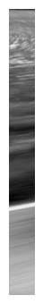

```python
# Select first half of the columns and all rows
image_cropped = image[:,:128]

# Show image
plt.imshow(image_cropped, cmap="gray"), plt.axis("off")
plt.show()
```

## Blurring Images

You want to smooth out an image.

[figure not shown]

```python
# Blur image
image_blurry = cv2.blur(image, (5,5))

# Show image
plt.imshow(image_blurry, cmap="gray"), plt.axis("off")
plt.show()
```

[figure not shown]

```python
# Blur image effect of kernel size
image_very_blurry = cv2.blur(image, (100,100))

# Show image
plt.imshow(image_very_blurry, cmap="gray"), plt.xticks([]), plt.yticks([])
plt.show()
```

## Sharpening Images

You want to sharpen an image.

[figure not shown]

```python
# Load image as grayscale
image = cv2.imread("car.jpg", cv2.IMREAD_GRAYSCALE)

# Create kernel
kernel = np.array([[0, -1, 0], [-1, 5,-1], [0, -1, 0]])

# Sharpen image
image_sharp = cv2.filter2D(image, -1, kernel)

# Show image
plt.imshow(image_sharp, cmap="gray"), plt.axis("off")
plt.show()
```

## Isolating Colors

You want to isolate a color in an image.

```python
# Load image
image_bgr = cv2.imread('car.jpg')

# Convert BGR to HSV
image_hsv = cv2.cvtColor(image_bgr, cv2.COLOR_BGR2HSV)

# Define range of blue values in HSV
lower_blue = np.array([50,100,50])
upper_blue = np.array([130,255,255])
```

```python
# Create mask
mask = cv2.inRange(image_hsv, lower_blue, upper_blue)

# Mask image
image_bgr_masked = cv2.bitwise_and(image_bgr, image_bgr, mask=mask)

# Convert BGR to RGB
image_rgb = cv2.cvtColor(image_bgr_masked, cv2.COLOR_BGR2RGB)
```

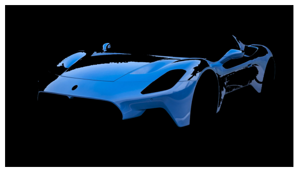

```python
# Show image
plt.imshow(image_rgb), plt.axis("off")
plt.show()
```

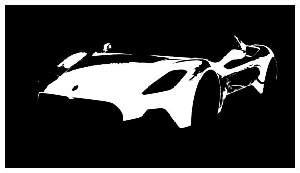

```python
# Show image in grayscale
plt.imshow(mask, cmap='gray'), plt.axis("off")
plt.show()
```

## Detecting Edges

You want to find the edges in an image.

```python
# Load image as grayscale
image_gray = cv2.imread("car.jpg", cv2.IMREAD_GRAYSCALE)
```

```python
# Calculate median intensity
median_intensity = np.median(image_gray)
```

```python
# Set thresholds to be one standard deviation above and below median intensity
lower_threshold = int(max(0, (1.0 - 0.33) * median_intensity))
upper_threshold = int(min(255, (1.0 + 0.33) * median_intensity))
```

```python
# Apply canny edge detector
image_canny = cv2.Canny(image_gray, lower_threshold, upper_threshold)
```

[figure not shown]

```python
# Show image
plt.imshow(image_canny, cmap="gray"), plt.axis("off")
plt.show()
```

## Detecting corners

You want to detect the corners in an image.

```python
# Load image as grayscale
image_bgr = cv2.imread("aero.jpg")
image_gray = cv2.cvtColor(image_bgr, cv2.COLOR_BGR2GRAY)
image_gray = np.float32(image_gray)
```

```python
# Set corner detector parameters
block_size = 2
aperture = 29
free_parameter = 0.04
```

```python
# Detect corners
detector_responses = cv2.cornerHarris(image_gray, block_size, aperture, free_parameter)
```

```python
# Large corner markers
detector_responses = cv2.dilate(detector_responses, None)
```

```python
# Only keep detector responses greater than threshold, mark as white
threshold = 0.02
image_bgr[detector_responses > threshold * detector_responses.max()] = [255,255,255]
```

```python
# Convert to grayscale
image_gray = cv2.cvtColor(image_bgr, cv2.COLOR_BGR2GRAY)
```

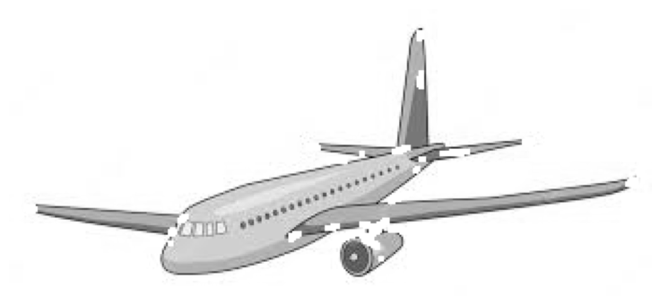

```python
# Show image
plt.imshow(image_gray, cmap="gray"), plt.axis("off")
plt.show()
```

## Creating Features for Machine Learning

You want to convert an image into an observation for machine learning.

```python
# Load image as grayscale
image = cv2.imread("car.jpg", cv2.IMREAD_GRAYSCALE)

# Resize image to 10 pixels by 10 pixels
image_10x10 = cv2.resize(image, (10, 10))

# Convert image data to one-dimensional vector
image_10x10.flatten()
```

```
array([140, 150, 139,  96, 102,  67,  44,  40,  33,  56, 173, 131, 170,
       130, 120,  98,  58,  48,  74,  69, 116, 128, 107, 119, 167,  59,
        25, 217, 112, 165, 111, 122, 194, 201, 188, 131, 133,  44,  91,
       167, 114, 204, 139, 105, 103,  78, 164, 231, 103, 178, 102, 132,
       120,  96, 123, 114, 100, 112,  20, 152,  71,  17,   9,  48,  63,
         8,  45, 138, 123, 146, 144,  42,  12,   2,  20,  63,  41, 133,
       150, 159, 165, 150, 130,  68,  60,  70, 134, 136, 166, 251, 187,
       178, 165, 164, 160, 157, 162, 162, 252, 181], dtype=uint8)
```

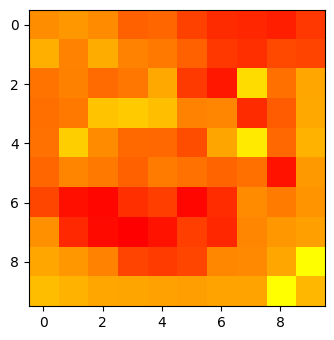

```python
plt.imshow(image_10x10, cmap="autumn")
plt.show()
```

```python
# Load image as grayscale
image = cv2.imread("car.jpg", cv2.IMREAD_COLOR)

# Resize image to 10 pixels by 10 pixels
image_10x10_color = cv2.resize(image, (10, 10))

# Convert image data to one-dimensional vector
image_10x10.flatten()
```

```
array([140, 150, 139,  96, 102,  67,  44,  40,  33,  56, 173, 131, 170,
       130, 120,  98,  58,  48,  74,  69, 116, 128, 107, 119, 167,  59,
        25, 217, 112, 165, 111, 122, 194, 201, 188, 131, 133,  44,  91,
       167, 114, 204, 139, 105, 103,  78, 164, 231, 103, 178, 102, 132,
       120,  96, 123, 114, 100, 112,  20, 152,  71,  17,   9,  48,  63,
         8,  45, 138, 123, 146, 144,  42,  12,   2,  20,  63,  41, 133,
       150, 159, 165, 150, 130,  68,  60,  70, 134, 136, 166, 251, 187,
       178, 165, 164, 160, 157, 162, 162, 252, 181], dtype=uint8)
```

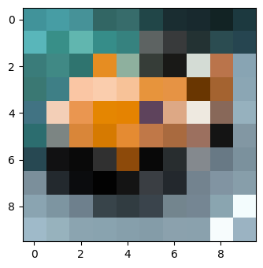

```python
plt.imshow(image_10x10_color, cmap="autumn")
plt.show()
```

```python
image_10x10.shape
```

```
(10, 10)
```

```python
image_10x10_color.shape
```

```
(10, 10, 3)
```

```python
image_10x10_color.flatten().shape
```

```
(300,)
```

## Encoding Mean Color as a Feature

You want a feature based on the colors of an image.

Each pixel in an image is represented by the combination of multiple color channels (often three: red, green, and blue). Calculate the mean red, green, and blue channel values for an image to make three color features representing the average colors in that image

```python
# Load image as BGR
image_bgr = cv2.imread("car.jpg", cv2.IMREAD_COLOR)

# Calculate the mean of each channel
channels = cv2.mean(image_bgr)

# Swap blue and red values (making it RGB, not BGR)
observation = np.array([(channels[2], channels[1], channels[0])])

# Show mean channel values
observation
```

```
array([[109.2743967 , 117.74593397, 109.68174913]])
```

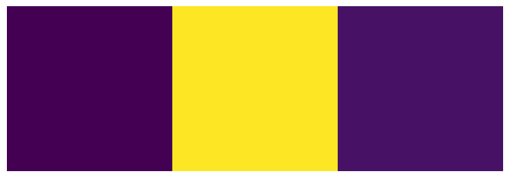

```python
# Show image
plt.imshow(observation), plt.axis("off")
plt.show()
```

The output is three feature values for an observation, one for each color channel in the image. These features can be used like any other features in learning algorithms to classify images according to their colors.

## Encoding Color Histograms as Features

You want to create a set of features representing the colors appearing in an image.

```python
# Load image
image_bgr = cv2.imread("car.jpg", cv2.IMREAD_COLOR)

# Convert to RGB
image_rgb = cv2.cvtColor(image_bgr, cv2.COLOR_BGR2RGB)

# Create a list for feature values
features = []

# Calculate the histogram for each color channel
colors = ("r","g","b")
```

```python
# For each channel: calculate histogram and add to feature value list
for i, channel in enumerate(colors):
  histogram = cv2.calcHist([image_rgb], # Image
  [i], # Index of channel
  None, # No mask
  [256], # Histogram size
  [0,256]) # Range
  features.extend(histogram)
```

```python
# Create a vector for an observation's feature values
observation = np.array(features).flatten()

# Show the observation's value for the first five features
observation[0:5]
```

```
array([62513., 44218., 30049., 16852., 13296.], dtype=float32)
```

In the RGB color model, each color is the combination of three color channels (i.e., red, green, blue). In turn, each channel can take on one of 256 values (represented by an integer between 0 and 255).

```python
image_rgb[0,0]
```

```
array([111, 101,  66], dtype=uint8)
```

```python
# Calculate the histogram for each color channel
colors = ("r","g","b")
```

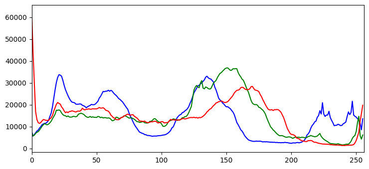

```python
img = cv2.imread('car.jpg')
color = ('b','g','r')
for i,col in enumerate(color):
 histr = cv2.calcHist([img],[i],None,[256],[0,256])
 plt.plot(histr,color = col)
 plt.xlim([0,256])
plt.show()
```